# worldhappinessproject1

2023-10-05

Hello, my name is Stephen Small and this will be my second project that I’ve done for the primary purpose of uploading to github. During this project I will be analyzing world happiness scores for the years 2015 to 2023 and investigating further perhaps what some of the contributing factors to hapinness is. The dataset(s) that I will be using can be found at kaggle.com via this link: https://www.kaggle.com/datasets/sazidthe1/global-happiness-scores-and-factors?select=WHR_2018.csv

During the course of this project I wil analyze the following:

1. The average happiness score for each year.
2. The top 10 happiness scores for each year.
3. The top 10 overall average happiness score by country.
4. Correlation of all factors to the happiness_score.
5. Average overall happiness score by region.
6. Line chart showing the trend of the happiness score by year.

The first thing I need to do is load and install all the necessary packages for this project…

Now to load them…

```r
library(tidyverse)
```

```r
library(tidyr)
library(dplyr)
library(ggplot2)
library(ggthemes)
library(janitor)
```

The next thing I am going to do is load all the datasets using the read.csv function.

```r
world_happiness2015 <- read.csv("~/Downloads/archive/WHR_2015.csv", sep = ",")

world_happiness2016 <- read.csv("~/Downloads/archive/WHR_2016.csv", sep = ",")

world_happiness2017 <- read.csv("~/Downloads/archive/WHR_2017.csv", sep = ",")

world_happiness2018 <- read.csv("~/Downloads/archive/WHR_2018.csv", sep = ",")

world_happiness2019 <- read.csv("~/Downloads/archive/WHR_2019.csv", sep = ",")

world_happiness2020 <- read.csv("~/Downloads/archive/WHR_2020.csv", sep = ",")

world_happiness2021 <- read.csv("~/Downloads/archive/WHR_2021.csv", sep = ",")

world_happiness2022 <- read.csv("~/Downloads/archive/WHR_2022.csv", sep = ",")

world_happiness2023 <- read.csv("~/Downloads/archive/WHR_2023.csv", sep = ",")
```

Now that the data is loaded I am going to check each table to see if they share the same column names.

```r
summary(world_happiness2015)
```

```
##    country             region          happiness_score gdp_per_capita
##  Length:158         Length:158         Min.   :2.839   Min.   :0.0000
##  Class :character   Class :character   1st Qu.:4.526   1st Qu.:0.5458
##  Mode  :character   Mode  :character   Median :5.232   Median :0.9102
##                                        Mean   :5.376   Mean   :0.8461
##                                        3rd Qu.:6.244   3rd Qu.:1.1584
##                                        Max.   :7.587   Max.   :1.6904
##  social_support   healthy_life_expectancy freedom_to_make_life_choices
##  Min.   :0.0000   Min.   :0.0000          Min.   :0.0000
##  1st Qu.:0.8568   1st Qu.:0.4392          1st Qu.:0.3283
##  Median :1.0295   Median :0.6967          Median :0.4355
##  Mean   :0.9910   Mean   :0.6303          Mean   :0.4286
##  3rd Qu.:1.2144   3rd Qu.:0.8110          3rd Qu.:0.5491
##  Max.   :1.4022   Max.   :1.0252          Max.   :0.6697
##    generosity     perceptions_of_corruption
##  Min.   :0.0000   Min.   :0.00000
##  1st Qu.:0.1506   1st Qu.:0.06168
##  Median :0.2161   Median :0.10722
##  Mean   :0.2373   Mean   :0.14342
##  3rd Qu.:0.3099   3rd Qu.:0.18025
##  Max.   :0.7959   Max.   :0.55191
```

```r
summary(world_happiness2016)
```

```
##    country             region          happiness_score gdp_per_capita
##  Length:157         Length:157         Min.   :2.905   Min.   :0.0000
##  Class :character   Class :character   1st Qu.:4.404   1st Qu.:0.6702
##  Mode  :character   Mode  :character   Median :5.314   Median :1.0278
##                                        Mean   :5.382   Mean   :0.9539
##                                        3rd Qu.:6.269   3rd Qu.:1.2796
##                                        Max.   :7.526   Max.   :1.8243
##  social_support   healthy_life_expectancy freedom_to_make_life_choices
##  Min.   :0.0000   Min.   :0.0000          Min.   :0.0000
##  1st Qu.:0.6418   1st Qu.:0.3829          1st Qu.:0.2575
##  Median :0.8414   Median :0.5966          Median :0.3975
##  Mean   :0.7936   Mean   :0.5576          Mean   :0.3710
##  3rd Qu.:1.0215   3rd Qu.:0.7299          3rd Qu.:0.4845
##  Max.   :1.1833   Max.   :0.9528          Max.   :0.6085
##    generosity     perceptions_of_corruption
##  Min.   :0.0000   Min.   :0.00000
##  1st Qu.:0.1546   1st Qu.:0.06126
##  Median :0.2225   Median :0.10547
##  Mean   :0.2426   Mean   :0.13762
##  3rd Qu.:0.3119   3rd Qu.:0.17554
##  Max.   :0.8197   Max.   :0.50521
```

```r
summary(world_happiness2017)
```

```
##    country             region          happiness_score gdp_per_capita
##  Length:155         Length:155         Min.   :2.693   Min.   :0.0000
##  Class :character   Class :character   1st Qu.:4.505   1st Qu.:0.6634
##  Mode  :character   Mode  :character   Median :5.279   Median :1.0646
##                                        Mean   :5.354   Mean   :0.9847
##                                        3rd Qu.:6.101   3rd Qu.:1.3180
##                                        Max.   :7.537   Max.   :1.8708
##  social_support  healthy_life_expectancy freedom_to_make_life_choices
##  Min.   :0.000   Min.   :0.0000          Min.   :0.0000
##  1st Qu.:1.043   1st Qu.:0.3699          1st Qu.:0.3037
##  Median :1.254   Median :0.6060          Median :0.4375
##  Mean   :1.189   Mean   :0.5513          Mean   :0.4088
##  3rd Qu.:1.414   3rd Qu.:0.7230          3rd Qu.:0.5166
##  Max.   :1.611   Max.   :0.9495          Max.   :0.6582
##    generosity     perceptions_of_corruption
##  Min.   :0.0000   Min.   :0.00000
##  1st Qu.:0.1541   1st Qu.:0.05727
##  Median :0.2315   Median :0.08985
##  Mean   :0.2469   Mean   :0.12312
##  3rd Qu.:0.3238   3rd Qu.:0.15330
##  Max.   :0.8381   Max.   :0.46431
```

```r
summary(world_happiness2018)
```

```
##    country             region          happiness_score gdp_per_capita
##  Length:156         Length:156         Min.   :2.905   Min.   :0.0000
##  Class :character   Class :character   1st Qu.:4.454   1st Qu.:0.6162
##  Mode  :character   Mode  :character   Median :5.378   Median :0.9495
##                                        Mean   :5.376   Mean   :0.8914
##                                        3rd Qu.:6.168   3rd Qu.:1.1978
##                                        Max.   :7.632   Max.   :2.0960
##  social_support  healthy_life_expectancy freedom_to_make_life_choices
##  Min.   :0.000   Min.   :0.0000          Min.   :0.0000
##  1st Qu.:1.067   1st Qu.:0.4223          1st Qu.:0.3560
##  Median :1.255   Median :0.6440          Median :0.4870
##  Mean   :1.213   Mean   :0.5973          Mean   :0.4545
##  3rd Qu.:1.463   3rd Qu.:0.7772          3rd Qu.:0.5785
##  Max.   :1.644   Max.   :1.0300          Max.   :0.7240
##    generosity     perceptions_of_corruption
##  Min.   :0.0000   Length:156
##  1st Qu.:0.1095   Class :character
##  Median :0.1740   Mode  :character
##  Mean   :0.1810
##  3rd Qu.:0.2390
##  Max.   :0.5980
```

```r
summary(world_happiness2019)
```

```
##    country             region          happiness_score gdp_per_capita
##  Length:156         Length:156         Min.   :2.853   Min.   :0.0000
##  Class :character   Class :character   1st Qu.:4.545   1st Qu.:0.6028
##  Mode  :character   Mode  :character   Median :5.380   Median :0.9600
##                                        Mean   :5.407   Mean   :0.9051
##                                        3rd Qu.:6.184   3rd Qu.:1.2325
##                                        Max.   :7.769   Max.   :1.6840
##  social_support  healthy_life_expectancy freedom_to_make_life_choices
##  Min.   :0.000   Min.   :0.0000          Min.   :0.0000
##  1st Qu.:1.056   1st Qu.:0.5477          1st Qu.:0.3080
##  Median :1.272   Median :0.7890          Median :0.4170
##  Mean   :1.209   Mean   :0.7252          Mean   :0.3926
##  3rd Qu.:1.452   3rd Qu.:0.8818          3rd Qu.:0.5072
##  Max.   :1.624   Max.   :1.1410          Max.   :0.6310
##    generosity     perceptions_of_corruption
##  Min.   :0.0000   Min.   :0.0000
##  1st Qu.:0.1087   1st Qu.:0.0470
##  Median :0.1775   Median :0.0855
##  Mean   :0.1848   Mean   :0.1106
##  3rd Qu.:0.2482   3rd Qu.:0.1412
##  Max.   :0.5660   Max.   :0.4530
```

```r
summary(world_happiness2020)
```

```
##    country             region          happiness_score gdp_per_capita
##  Length:153         Length:153         Min.   :2.567   Min.   :0.0000
##  Class :character   Class :character   1st Qu.:4.724   1st Qu.:0.5759
##  Mode  :character   Mode  :character   Median :5.515   Median :0.9185
##                                        Mean   :5.473   Mean   :0.8688
##                                        3rd Qu.:6.229   3rd Qu.:1.1692
##                                        Max.   :7.809   Max.   :1.5367
##  social_support   healthy_life_expectancy freedom_to_make_life_choices
##  Min.   :0.0000   Min.   :0.0000          Min.   :0.0000
##  1st Qu.:0.9867   1st Qu.:0.4954          1st Qu.:0.3815
##  Median :1.2040   Median :0.7598          Median :0.4833
##  Mean   :1.1556   Mean   :0.6929          Mean   :0.4636
##  3rd Qu.:1.3871   3rd Qu.:0.8672          3rd Qu.:0.5767
##  Max.   :1.5476   Max.   :1.1378          Max.   :0.6933
##    generosity     perceptions_of_corruption
##  Min.   :0.0000   Min.   :0.00000
##  1st Qu.:0.1150   1st Qu.:0.05580
##  Median :0.1767   Median :0.09844
##  Mean   :0.1894   Mean   :0.13072
##  3rd Qu.:0.2555   3rd Qu.:0.16306
##  Max.   :0.5698   Max.   :0.53316
```

```r
summary(world_happiness2021)
```

```
##    country             region          happiness_score gdp_per_capita
##  Length:149         Length:149         Min.   :2.523   Min.   :0.0000
##  Class :character   Class :character   1st Qu.:4.852   1st Qu.:0.6660
##  Mode  :character   Mode  :character   Median :5.534   Median :1.0250
##                                        Mean   :5.533   Mean   :0.9772
##                                        3rd Qu.:6.255   3rd Qu.:1.3230
##                                        Max.   :7.842   Max.   :1.7510
##  social_support   healthy_life_expectancy freedom_to_make_life_choices
##  Min.   :0.0000   Min.   :0.0000          Min.   :0.0000
##  1st Qu.:0.6470   1st Qu.:0.3570          1st Qu.:0.4090
##  Median :0.8320   Median :0.5710          Median :0.5140
##  Mean   :0.7933   Mean   :0.5202          Mean   :0.4987
##  3rd Qu.:0.9960   3rd Qu.:0.6650          3rd Qu.:0.6030
##  Max.   :1.1720   Max.   :0.8970          Max.   :0.7160
##    generosity    perceptions_of_corruption
##  Min.   :0.000   Min.   :0.0000
##  1st Qu.:0.105   1st Qu.:0.0600
##  Median :0.164   Median :0.1010
##  Mean   :0.178   Mean   :0.1351
##  3rd Qu.:0.239   3rd Qu.:0.1740
##  Max.   :0.541   Max.   :0.5470
```

```r
summary(world_happiness2022)
```

```
##    country             region          happiness_score gdp_per_capita
##  Length:146         Length:146         Min.   :2.404   Min.   :0.000
##  Class :character   Class :character   1st Qu.:4.889   1st Qu.:1.095
##  Mode  :character   Mode  :character   Median :5.569   Median :1.446
##                                        Mean   :5.554   Mean   :1.410
##                                        3rd Qu.:6.305   3rd Qu.:1.785
##                                        Max.   :7.821   Max.   :2.209
##  social_support   healthy_life_expectancy freedom_to_make_life_choices
##  Min.   :0.0000   Min.   :0.0000          Min.   :0.0000
##  1st Qu.:0.7320   1st Qu.:0.4632          1st Qu.:0.4405
##  Median :0.9575   Median :0.6215          Median :0.5435
##  Mean   :0.9059   Mean   :0.5862          Mean   :0.5172
##  3rd Qu.:1.1142   3rd Qu.:0.7198          3rd Qu.:0.6260
##  Max.   :1.3200   Max.   :0.9420          Max.   :0.7400
##    generosity     perceptions_of_corruption
##  Min.   :0.0000   Min.   :0.00000
##  1st Qu.:0.0890   1st Qu.:0.06825
##  Median :0.1325   Median :0.11950
##  Mean   :0.1474   Mean   :0.15478
##  3rd Qu.:0.1978   3rd Qu.:0.19850
##  Max.   :0.4680   Max.   :0.58700
```

```r
summary(world_happiness2023)
```

```
##    country             region          happiness_score gdp_per_capita
##  Length:137         Length:137         Min.   :1.859   Min.   :0.000
##  Class :character   Class :character   1st Qu.:4.724   1st Qu.:1.099
##  Mode  :character   Mode  :character   Median :5.684   Median :1.449
##                                        Mean   :5.540   Mean   :1.407
##                                        3rd Qu.:6.334   3rd Qu.:1.798
##                                        Max.   :7.804   Max.   :2.200
##
##  social_support  healthy_life_expectancy freedom_to_make_life_choices
##  Min.   :0.000   Min.   :0.0000          Min.   :0.000
##  1st Qu.:0.962   1st Qu.:0.2485          1st Qu.:0.455
##  Median :1.227   Median :0.3895          Median :0.557
##  Mean   :1.156   Mean   :0.3662          Mean   :0.540
##  3rd Qu.:1.401   3rd Qu.:0.4875          3rd Qu.:0.656
##  Max.   :1.620   Max.   :0.7020          Max.   :0.772
##                  NA's   :1
##    generosity     perceptions_of_corruption
##  Min.   :0.0000   Min.   :0.0000
##  1st Qu.:0.0970   1st Qu.:0.0600
##  Median :0.1370   Median :0.1110
##  Mean   :0.1485   Mean   :0.1459
##  3rd Qu.:0.1990   3rd Qu.:0.1870
##  Max.   :0.4220   Max.   :0.5610
##
```

After reviewing all the tables, I can see they all share the same column names which makes joining the tables a little easier. First I will need to add a year column and the corresponding year for each table to be able to identiy them better when I join the tables.

```r
world_happiness2015v1 <- world_happiness2015%>%
  mutate(year = 2015)

world_happiness2016v1 <- world_happiness2016%>%
  mutate(year = 2016)

world_happiness2017v1 <- world_happiness2017%>%
  mutate(year = 2017)

world_happiness2018v1 <- world_happiness2018%>%
  mutate(year = 2018)

world_happiness2019v1 <- world_happiness2019%>%
  mutate(year = 2019)

world_happiness2020v1 <- world_happiness2020%>%
  mutate(year = 2020)

world_happiness2021v1 <- world_happiness2021%>%
  mutate(year = 2021)

world_happiness2022v1 <- world_happiness2022%>%
  mutate(year = 2022)

world_happiness2023v1 <- world_happiness2023%>%
  mutate(year = 2023)
```

Now I will join them all together with union…

```r
world_happiness <- union( world_happiness2015v1, world_happiness2016v1)

world_happinessv1 <- union(world_happiness, world_happiness2017v1)

world_happinessv2 <- union(world_happinessv1, world_happiness2018v1)

world_happinessv3 <- union(world_happinessv2, world_happiness2019v1)

world_happinessv4 <- union(world_happinessv3, world_happiness2020v1)

world_happinessv5 <- union(world_happinessv4, world_happiness2021v1)

world_happinessv6 <- union(world_happinessv5, world_happiness2022v1)

world_happinessv7 <- union(world_happinessv6, world_happiness2023v1)
```

After trying to unionize the world_happinessv1 table with worldhappiness2018v1, I find that the data types for the ‘perceptions of corruption’ column are different. So I will change the data type to match.

```r
world_happiness2018v1$perceptions_of_corruption = as.numeric(as.character(world_happiness2018v1$perceptions_of_corruption))
```

now to rerun the previous queries…

Now that I’ve done that, I will begin the process of cleaning and validating the data. First, I will begin by checking to see if all the columns are in their proper format and also check for any null values.

```r
summary(world_happinessv7)
```

```
##    country             region          happiness_score gdp_per_capita
##  Length:1367        Length:1367        Min.   :1.859   Min.   :0.0000
##  Class :character   Class :character   1st Qu.:4.599   1st Qu.:0.6963
##  Mode  :character   Mode  :character   Median :5.440   Median :1.0430
##                                        Mean   :5.441   Mean   :1.0194
##                                        3rd Qu.:6.256   3rd Qu.:1.3385
##                                        Max.   :7.842   Max.   :2.2090
##
##  social_support  healthy_life_expectancy freedom_to_make_life_choices
##  Min.   :0.000   Min.   :0.0000          Min.   :0.0000
##  1st Qu.:0.832   1st Qu.:0.4023          1st Qu.:0.3560
##  Median :1.083   Median :0.6128          Median :0.4676
##  Mean   :1.045   Mean   :0.5840          Mean   :0.4508
##  3rd Qu.:1.300   3rd Qu.:0.7776          3rd Qu.:0.5687
##  Max.   :1.644   Max.   :1.1410          Max.   :0.7720
##                  NA's   :1
##    generosity     perceptions_of_corruption      year
##  Min.   :0.0000   Min.   :0.00000           Min.   :2015
##  1st Qu.:0.1150   1st Qu.:0.05683           1st Qu.:2017
##  Median :0.1827   Median :0.09700           Median :2019
##  Mean   :0.1963   Mean   :0.13227           Mean   :2019
##  3rd Qu.:0.2529   3rd Qu.:0.16595           3rd Qu.:2021
##  Max.   :0.8381   Max.   :0.58700           Max.   :2023
##                   NA's   :1
```

After running the summary function, I find that all the columns are in an acceptable format and that there are 2 null values throughout the whole dataset. There is one null value in the perceptions of corruption dataset. I will replace that null value with the average perceptions of corruption value of 0.13227. In addition to the perceptions of corruption column, there is also a null value in the healthy life expectancy column. I will also replace that value with the average life expectancy of 0.5840.

```r
world_happinessv8 <- world_happinessv7%>%
  mutate(healthy_life_expectancy = coalesce(healthy_life_expectancy, 0.5840), perceptions_of_corruption = coalesce(perceptions_of_corruption, 0.13227))
```

Now to run summary to confirm…

```r
summary(world_happinessv8)
```

```
##    country             region          happiness_score gdp_per_capita
##  Length:1367        Length:1367        Min.   :1.859   Min.   :0.0000
##  Class :character   Class :character   1st Qu.:4.599   1st Qu.:0.6963
##  Mode  :character   Mode  :character   Median :5.440   Median :1.0430
##                                        Mean   :5.441   Mean   :1.0194
##                                        3rd Qu.:6.256   3rd Qu.:1.3385
##                                        Max.   :7.842   Max.   :2.2090
##  social_support  healthy_life_expectancy freedom_to_make_life_choices
##  Min.   :0.000   Min.   :0.0000          Min.   :0.0000
##  1st Qu.:0.832   1st Qu.:0.4026          1st Qu.:0.3560
##  Median :1.083   Median :0.6124          Median :0.4676
##  Mean   :1.045   Mean   :0.5840          Mean   :0.4508
##  3rd Qu.:1.300   3rd Qu.:0.7776          3rd Qu.:0.5687
##  Max.   :1.644   Max.   :1.1410          Max.   :0.7720
##    generosity     perceptions_of_corruption      year
##  Min.   :0.0000   Min.   :0.00000           Min.   :2015
##  1st Qu.:0.1150   1st Qu.:0.05688           1st Qu.:2017
##  Median :0.1827   Median :0.09700           Median :2019
##  Mean   :0.1963   Mean   :0.13227           Mean   :2019
##  3rd Qu.:0.2529   3rd Qu.:0.16589           3rd Qu.:2021
##  Max.   :0.8381   Max.   :0.58700           Max.   :2023
```

After checking and fixing any null values, I will check for and remove any duplicates with the get_dupes function from the janitor package.

```r
world_happinessv8%>%
  get_dupes(
  )
```

```
## No variable names specified - using all columns.
```

```
## No duplicate combinations found of: country, region, happiness_score, gdp_per_capita, social_support, healthy_life_expectancy, freedom_to_make_life_choices, generosity, perceptions_of_corruption, year
```

```
##  [1] country                      region
##  [3] happiness_score              gdp_per_capita
##  [5] social_support               healthy_life_expectancy
##  [7] freedom_to_make_life_choices generosity
##  [9] perceptions_of_corruption    year
## [11] dupe_count
## <0 rows> (or 0-length row.names)
```

After running the query, I find that there are no duplicates in this dataset. Next, I am going to check for any missplaced values or any typos that may be in the dataset. I will check each column one by one…

```r
world_happinessv8%>%
  count(country)
```

```
##                       country  n
## 1                 Afghanistan  9
## 2                     Albania  9
## 3                     Algeria  9
## 4                      Angola  4
## 5                   Argentina  9
## 6                     Armenia  9
## 7                   Australia  9
## 8                     Austria  9
## 9                  Azerbaijan  8
## 10                    Bahrain  9
## 11                 Bangladesh  9
## 12                    Belarus  8
## 13                    Belgium  9
## 14                     Belize  3
```

[output cut: 157 more lines]

After running the query I find that there are three different ‘Congo’ s in the dataset, ‘Congo’ by itself, Congo (Brazzaville), and Congo(Kinshasha). One of the things I need to figure out is which country the ‘Congo’ by itself goes to, so I will investigate that further…

```r
world_happinessv8%>%
  filter(country == "Congo")
```

```
##   country             region happiness_score gdp_per_capita social_support
## 1   Congo Sub-Saharan Africa           5.075           0.95          0.405
##   healthy_life_expectancy freedom_to_make_life_choices generosity
## 1                   0.355                        0.431       0.13
##   perceptions_of_corruption year
## 1                     0.146 2022
```

Now to look at the other “Congo’s” for any clues to which country this likely belongs to…

```r
world_happinessv8%>%
  filter(country == "Congo (Brazzaville)")
```

```
##               country             region happiness_score gdp_per_capita
## 1 Congo (Brazzaville) Sub-Saharan Africa          3.9890      0.6786600
## 2 Congo (Brazzaville) Sub-Saharan Africa          4.2360      0.7710900
## 3 Congo (Brazzaville) Sub-Saharan Africa          4.2910      0.8089643
## 4 Congo (Brazzaville) Sub-Saharan Africa          4.5590      0.6820000
## 5 Congo (Brazzaville) Sub-Saharan Africa          4.8120      0.6730000
## 6 Congo (Brazzaville) Sub-Saharan Africa          5.1944      0.6336167
## 7 Congo (Brazzaville) Sub-Saharan Africa          5.3420      0.5180000
## 8 Congo (Brazzaville) Sub-Saharan Africa          5.2670      0.9210000
##   social_support healthy_life_expectancy freedom_to_make_life_choices
## 1      0.6629000               0.3105100                    0.4146600
## 2      0.4779900               0.2821200                    0.3793800
## 3      0.8320444               0.2899574                    0.4350259
## 4      0.8110000               0.3430000                    0.5140000
## 5      0.7990000               0.5080000                    0.3720000
## 6      0.7576360               0.4581011                    0.3865144
## 7      0.3920000               0.3070000                    0.3810000
## 8      0.6650000               0.1450000                    0.4640000
##   generosity perceptions_of_corruption year
## 1  0.1238800                0.11686000 2015
## 2  0.1207700                0.09753000 2016
## 3  0.1208521                0.07961813 2017
## 4  0.0910000                0.07700000 2018
## 5  0.1050000                0.09300000 2019
## 6  0.1172160                0.11867078 2020
## 7  0.1440000                0.12400000 2021
## 8  0.1340000                0.13600000 2023
```

Now Congo (Kinshasha)…

```r
world_happinessv8%>%
  filter(country == "Congo (Kinshasa)")
```

```
##            country             region happiness_score gdp_per_capita
## 1 Congo (Kinshasa) Sub-Saharan Africa           4.517     0.00000000
## 2 Congo (Kinshasa) Sub-Saharan Africa           4.272     0.05661000
## 3 Congo (Kinshasa) Sub-Saharan Africa           4.280     0.09210235
## 4 Congo (Kinshasa) Sub-Saharan Africa           4.245     0.06900000
## 5 Congo (Kinshasa) Sub-Saharan Africa           4.418     0.09400000
## 6 Congo (Kinshasa) Sub-Saharan Africa           4.311     0.06248747
## 7 Congo (Kinshasa) Sub-Saharan Africa           3.207     0.53100000
##   social_support healthy_life_expectancy freedom_to_make_life_choices
## 1       1.001200               0.0980600                    0.2260500
## 2       0.806760               0.1880000                    0.1560200
## 3       1.229023               0.1914070                    0.2359613
## 4       1.136000               0.2040000                    0.3120000
## 5       1.125000               0.3570000                    0.2690000
## 6       0.833055               0.2772121                    0.3646230
## 7       0.784000               0.1050000                    0.3750000
##   generosity perceptions_of_corruption year
## 1  0.2483400                0.07625000 2015
## 2  0.2545800                0.06075000 2016
## 3  0.2464558                0.06024136 2017
## 4  0.1970000                0.05200000 2018
## 5  0.2120000                0.05300000 2019
## 6  0.2543249                0.08146665 2020
## 7  0.1830000                0.06800000 2023
```

After looking at the two rows it appears that ‘Congo’ is supposed to be ‘Congo (Brazzaville)’ for a couple of reasons. First is that ‘Congo (Brazzaville)’ has a record for every row except 2022 which is the year that the ‘Congo’ record has, and second, the numbers seem to fall more in line with the ‘Congo (Brazzaville)’ records as well. The next thing I will do is change the name from ‘Congo’ to ‘Congo (Brazzavillle)’.

```r
world_happinessv8$country[world_happinessv8$country == 'Congo'] <- 'Congo (Brazzaville)'
```

now to double check, there should be 9 records…

```r
world_happinessv8%>%
  filter(country == "Congo (Brazzaville)")
```

```
##               country             region happiness_score gdp_per_capita
## 1 Congo (Brazzaville) Sub-Saharan Africa          3.9890      0.6786600
## 2 Congo (Brazzaville) Sub-Saharan Africa          4.2360      0.7710900
## 3 Congo (Brazzaville) Sub-Saharan Africa          4.2910      0.8089643
## 4 Congo (Brazzaville) Sub-Saharan Africa          4.5590      0.6820000
## 5 Congo (Brazzaville) Sub-Saharan Africa          4.8120      0.6730000
## 6 Congo (Brazzaville) Sub-Saharan Africa          5.1944      0.6336167
## 7 Congo (Brazzaville) Sub-Saharan Africa          5.3420      0.5180000
## 8 Congo (Brazzaville) Sub-Saharan Africa          5.0750      0.9500000
## 9 Congo (Brazzaville) Sub-Saharan Africa          5.2670      0.9210000
##   social_support healthy_life_expectancy freedom_to_make_life_choices
## 1      0.6629000               0.3105100                    0.4146600
## 2      0.4779900               0.2821200                    0.3793800
## 3      0.8320444               0.2899574                    0.4350259
## 4      0.8110000               0.3430000                    0.5140000
## 5      0.7990000               0.5080000                    0.3720000
## 6      0.7576360               0.4581011                    0.3865144
## 7      0.3920000               0.3070000                    0.3810000
## 8      0.4050000               0.3550000                    0.4310000
## 9      0.6650000               0.1450000                    0.4640000
##   generosity perceptions_of_corruption year
## 1  0.1238800                0.11686000 2015
## 2  0.1207700                0.09753000 2016
## 3  0.1208521                0.07961813 2017
## 4  0.0910000                0.07700000 2018
## 5  0.1050000                0.09300000 2019
## 6  0.1172160                0.11867078 2020
## 7  0.1440000                0.12400000 2021
## 8  0.1300000                0.14600000 2022
## 9  0.1340000                0.13600000 2023
```

Now that it’s fixed , I will check again for any mistakes that were done by counting the country column once again…

```r
world_happinessv8%>%
  count(country)
```

```
##                       country  n
## 1                 Afghanistan  9
## 2                     Albania  9
## 3                     Algeria  9
## 4                      Angola  4
## 5                   Argentina  9
## 6                     Armenia  9
## 7                   Australia  9
## 8                     Austria  9
## 9                  Azerbaijan  8
## 10                    Bahrain  9
## 11                 Bangladesh  9
## 12                    Belarus  8
## 13                    Belgium  9
## 14                     Belize  3
```

[output cut: 156 more lines]

The only other mistake I see in the country column is that there is another name used for the ‘Turkey’ column. After doing research I found that in 2022 ‘Turkey’ officially changed there name to ‘Turkiye’, so in the interest of keeping everything uniform in this dataset, I will change the name to what is now the official name of ‘Turkiye’…

```r
world_happinessv8$country[world_happinessv8$country == 'Turkey'] <- 'Turkiye'
```

Now I will double check to see if it was indeed changed, there should be 9 records now…

```r
world_happinessv8%>%
  filter(country == 'Turkiye')
```

```
##   country                       region happiness_score gdp_per_capita
## 1 Turkiye Middle East and North Africa          5.3320       1.060980
## 2 Turkiye Middle East and North Africa          5.3890       1.164920
## 3 Turkiye Middle East and North Africa          5.5000       1.198274
## 4 Turkiye Middle East and North Africa          5.4830       1.148000
## 5 Turkiye Middle East and North Africa          5.3730       1.183000
## 6 Turkiye Middle East and North Africa          5.1318       1.127169
## 7 Turkiye Middle East and North Africa          4.9480       1.260000
## 8 Turkiye Middle East and North Africa          4.7440       1.707000
## 9 Turkiye Middle East and North Africa          4.6140       1.714000
##   social_support healthy_life_expectancy freedom_to_make_life_choices
## 1       0.946320               0.7317200                    0.2281500
## 2       0.877170               0.6471800                    0.2388900
## 3       1.337753               0.6376056                    0.3007406
## 4       1.380000               0.6860000                    0.3240000
## 5       1.360000               0.8080000                    0.1950000
## 6       1.197159               0.7813353                    0.2544008
## 7       0.809000               0.5900000                    0.2360000
## 8       0.865000               0.7020000                    0.2090000
## 9       1.148000               0.4670000                    0.1250000
##   generosity perceptions_of_corruption year
## 1 0.12253000                0.15746000 2015
## 2 0.04707000                0.12348000 2016
## 3 0.04669304                0.09967158 2017
## 4 0.10600000                0.10900000 2018
## 5 0.08300000                0.10600000 2019
## 6 0.08588557                0.12098324 2020
## 7 0.09700000                0.10400000 2021
## 8 0.08700000                0.11500000 2022
## 9 0.09500000                0.09600000 2023
```

Now to triple check country column…

```r
world_happinessv8 %>%
  count(country)
```

```
##                       country  n
## 1                 Afghanistan  9
## 2                     Albania  9
## 3                     Algeria  9
## 4                      Angola  4
## 5                   Argentina  9
## 6                     Armenia  9
## 7                   Australia  9
## 8                     Austria  9
## 9                  Azerbaijan  8
## 10                    Bahrain  9
## 11                 Bangladesh  9
## 12                    Belarus  8
## 13                    Belgium  9
## 14                     Belize  3
```

[output cut: 155 more lines]

After checking again for any errors I notice that one of the ‘Somaliland Region’(on p. 14 of tibble) is not completely in titlecase so I will fix that.

```r
world_happinessv8$country[world_happinessv8$country == 'Somaliland region'] <- 'Somaliland Region'
```

Now to double check the to make sure, there should be two observations…

```r
world_happinessv8 %>%
  filter(country == "Somaliland Region")
```

```
##             country region happiness_score gdp_per_capita social_support
## 1 Somaliland Region Africa           5.057        0.18847        0.95152
## 2 Somaliland Region Africa           5.057        0.25558        0.75862
##   healthy_life_expectancy freedom_to_make_life_choices generosity
## 1                 0.43873                      0.46582    0.50318
## 2                 0.33108                      0.39130    0.51479
##   perceptions_of_corruption year
## 1                   0.39928 2015
## 2                   0.36794 2016
```

After checking to see if there were anymore errors, there was none that I’ve observed. Now, I will check the region column…

```r
world_happinessv8%>%
  count(region)
```

```
##                                region   n
## 1                              Africa   2
## 2          Central and Eastern Europe 214
## 3  Commonwealth of Independent States  44
## 4                           East Asia  54
## 5         Latin America and Caribbean 190
## 6        Middle East and North Africa 161
## 7               North America and ANZ  36
## 8                          South Asia  61
## 9                      Southeast Asia  80
## 10                 Sub-Saharan Africa 337
## 11                     Western Europe 188
```

No errors there, which will conclude the cleaning part of my analysis of the happiness_score table. Next I will begin analyzing. First thing I am going to do is find the overall average happiness score for each year.

```r
avg_hap_countby <- world_happinessv8%>%
  group_by(year) %>%
  summarize(avg_happiness_score = mean(happiness_score))

print(avg_hap_countby)
```

```
## # A tibble: 9 × 2
##    year avg_happiness_score
##   <dbl>               <dbl>
## 1  2015                5.38
## 2  2016                5.38
## 3  2017                5.35
## 4  2018                5.38
## 5  2019                5.41
## 6  2020                5.47
## 7  2021                5.53
## 8  2022                5.55
## 9  2023                5.54
```

After viewing the numbers it appearing that overall happiness score has gone up little by little up until 2021 where it stayed around the same until 2023. I will visualize this with a line plot using the ggplot package.

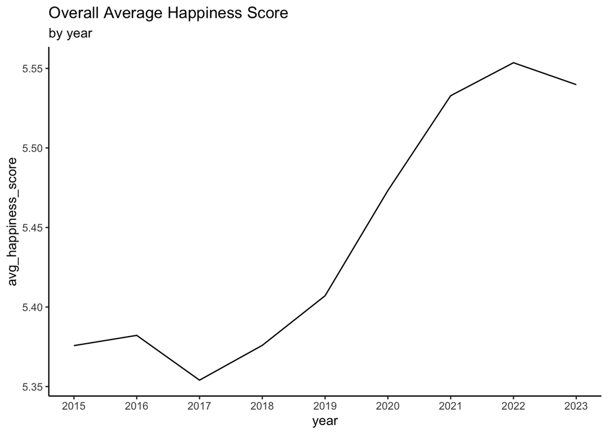

```r
avg_hap_countbyviz <- ggplot(avg_hap_countby, aes(year, avg_happiness_score))+
  geom_line(stat = "identity")+
  theme_classic()+
  scale_x_continuous(breaks = seq(2015, 2023, by = 1))+
  labs(title = "Overall Average Happiness Score", subtitle = "by year")


print(avg_hap_countbyviz)
```

After viewing the line chart you can see an increase of the happiness score from 2017 to 2021, after which it began to plateau a little. Now,I would like to figure out what are the top ten happiness score for each year.

```r
top10_hap_ey <- world_happinessv8 %>%
  group_by(year) %>%
  slice_max(happiness_score, n = 10)

print(top10_hap_ey)
```

```
## # A tibble: 90 × 10
## # Groups:   year [9]
##    country     region              happiness_score gdp_per_capita social_support
##    <chr>       <chr>                         <dbl>          <dbl>          <dbl>
##  1 Switzerland Western Europe                 7.59           1.40           1.35
##  2 Iceland     Western Europe                 7.56           1.30           1.40
##  3 Denmark     Western Europe                 7.53           1.33           1.36
##  4 Norway      Western Europe                 7.52           1.46           1.33
##  5 Canada      North America and …            7.43           1.33           1.32
##  6 Finland     Western Europe                 7.41           1.29           1.32
##  7 Netherlands Western Europe                 7.38           1.33           1.28
##  8 Sweden      Western Europe                 7.36           1.33           1.29
##  9 New Zealand North America and …            7.29           1.25           1.32
## 10 Australia   North America and …            7.28           1.33           1.31
## # ℹ 80 more rows
## # ℹ 5 more variables: healthy_life_expectancy <dbl>,
## #   freedom_to_make_life_choices <dbl>, generosity <dbl>,
## #   perceptions_of_corruption <dbl>, year <dbl>
```

After viewing the results of this query, one of the things that is clear is that many of the same countries are on this list each year. Denmark who is number 3 on this list doesnt fall below 3 in any year on this dataset. The distribution is alot clearer to see when visualized with a histogram…

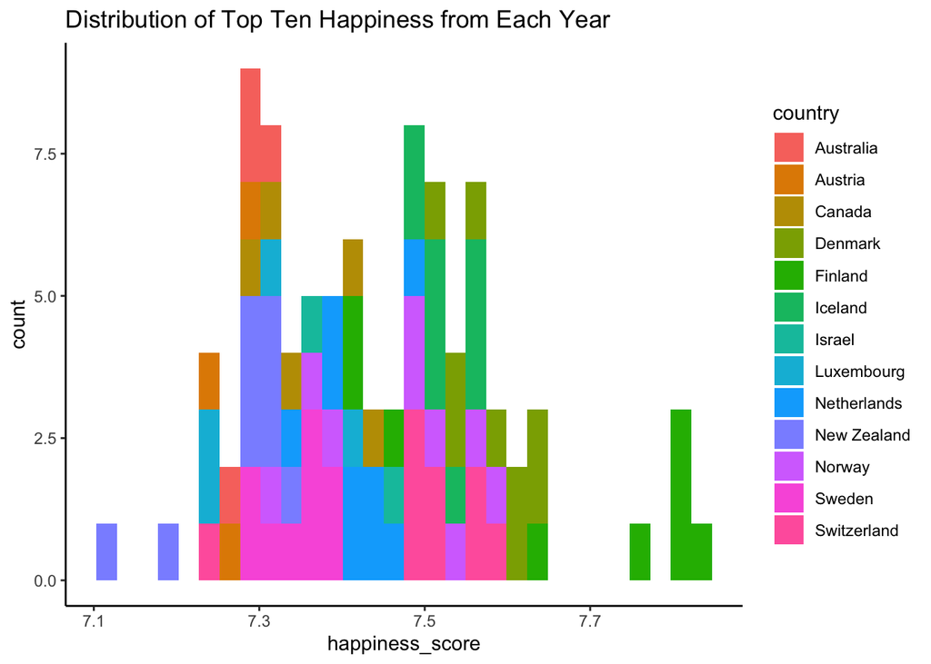

```r
top10_hap_eyviz <- ggplot(top10_hap_ey, aes(happiness_score, fill = country))+
  geom_histogram(bins = 30)+
  theme_classic()+
  labs(title = "Distribution of Top Ten Happiness from Each Year")
print(top10_hap_eyviz)
```

One of the things that is interesting is of the 9 years that I have a top ten list for, there are only 13 different countries which means there is very little turnover from this list, so countries on this list seem to consistently stay on this list, which begs the question. Why is that? In order to figure this out I need to figure out which factor contributes to happiness by finding out which factor most positively correlates with the happiness score. In order to do that I will create a corrletion chart for the whole dataset…

```r
library(corrr)

happiness_score_corr<- world_happinessv8 %>%
  select(happiness_score, gdp_per_capita, social_support, healthy_life_expectancy, freedom_to_make_life_choices, generosity, perceptions_of_corruption) %>%
  correlate()
```

```
## Correlation computed with
## • Method: 'pearson'
## • Missing treated using: 'pairwise.complete.obs'
```

```r
print(happiness_score_corr)
```

```
## # A tibble: 7 × 8
##   term      happiness_score gdp_per_capita social_support healthy_life_expecta…¹
##   <chr>               <dbl>          <dbl>          <dbl>                  <dbl>
## 1 happines…         NA               0.724        0.648                   0.682
## 2 gdp_per_…          0.724          NA            0.522                   0.565
## 3 social_s…          0.648           0.522       NA                       0.561
## 4 healthy_…          0.682           0.565        0.561                  NA
## 5 freedom_…          0.569           0.439        0.365                   0.261
## 6 generosi…          0.0823         -0.154       -0.00638                 0.0259
## 7 percepti…          0.415           0.337        0.147                   0.256
## # ℹ abbreviated name: ¹healthy_life_expectancy
## # ℹ 3 more variables: freedom_to_make_life_choices <dbl>, generosity <dbl>,
## #   perceptions_of_corruption <dbl>
```

After looking at the correlation chart, it appears that gdp per capita is the factor that most positively correlates with the dataset as a whole. But what about the least happy countries vs. the most happy countries, what factors into the happiness score for each? The first thing I would like to figure out is what most positively correlates for the top countries in the dataset. I will take the top 50 countries from each year in terms of happiness and create a correlation table for it…

```r
top50happinesscoreby <- world_happinessv8 %>%
  group_by(year) %>%
  slice_max(happiness_score, n = 50)

print(top50happinesscoreby)
```

```
## # A tibble: 450 × 10
## # Groups:   year [9]
##    country     region              happiness_score gdp_per_capita social_support
##    <chr>       <chr>                         <dbl>          <dbl>          <dbl>
##  1 Switzerland Western Europe                 7.59           1.40           1.35
##  2 Iceland     Western Europe                 7.56           1.30           1.40
##  3 Denmark     Western Europe                 7.53           1.33           1.36
##  4 Norway      Western Europe                 7.52           1.46           1.33
##  5 Canada      North America and …            7.43           1.33           1.32
##  6 Finland     Western Europe                 7.41           1.29           1.32
##  7 Netherlands Western Europe                 7.38           1.33           1.28
##  8 Sweden      Western Europe                 7.36           1.33           1.29
##  9 New Zealand North America and …            7.29           1.25           1.32
## 10 Australia   North America and …            7.28           1.33           1.31
## # ℹ 440 more rows
## # ℹ 5 more variables: healthy_life_expectancy <dbl>,
## #   freedom_to_make_life_choices <dbl>, generosity <dbl>,
## #   perceptions_of_corruption <dbl>, year <dbl>
```

Now to run a correlation table…

```r
happiness_score_corrt50 <- top50happinesscoreby %>%
  select(happiness_score, gdp_per_capita, social_support, healthy_life_expectancy, freedom_to_make_life_choices, generosity, perceptions_of_corruption) %>%
correlate()
```

```
## Correlation computed with • Method: 'pearson' • Missing treated using:
## 'pairwise.complete.obs'
```

```r
print(happiness_score_corrt50)
```

```
## # A tibble: 8 × 9
##   term                        year happiness_score gdp_per_capita social_support
##   <chr>                      <dbl>           <dbl>          <dbl>          <dbl>
## 1 year                    NA              -0.00741         0.501          0.0543
## 2 happiness_score         -0.00741        NA               0.348          0.261
## 3 gdp_per_capita           0.501           0.348          NA              0.0660
## 4 social_support           0.0543          0.261           0.0660        NA
## 5 healthy_life_expectancy -0.382           0.373          -0.140          0.283
## 6 freedom_to_make_life_c…  0.382           0.448           0.327          0.144
## 7 generosity              -0.424           0.414          -0.0493         0.137
## 8 perceptions_of_corrupt…  0.0368          0.639           0.427          0.121
## # ℹ 4 more variables: healthy_life_expectancy <dbl>,
## #   freedom_to_make_life_choices <dbl>, generosity <dbl>,
## #   perceptions_of_corruption <dbl>
```

After running the correlation table, the results are different than from what I expected. When just taking a sample of the top 50 from each year, the factor that most positively correlates to the happiness score is perceptions of corruption. Now, what about the bottom 50 countries by year in terms of happiness…

```r
bottom50happinessscoreby <- world_happinessv8 %>%
  group_by(year) %>%
  slice_min(happiness_score, n = 50)

print(bottom50happinessscoreby)
```

```
## # A tibble: 451 × 10
## # Groups:   year [9]
##    country      region             happiness_score gdp_per_capita social_support
##    <chr>        <chr>                        <dbl>          <dbl>          <dbl>
##  1 Togo         Sub-Saharan Africa            2.84         0.209           0.140
##  2 Burundi      Sub-Saharan Africa            2.90         0.0153          0.416
##  3 Syria        Middle East and N…            3.01         0.663           0.475
##  4 Benin        Sub-Saharan Africa            3.34         0.287           0.354
##  5 Rwanda       Sub-Saharan Africa            3.46         0.222           0.774
##  6 Afghanistan  South Asia                    3.58         0.320           0.303
##  7 Burkina Faso Sub-Saharan Africa            3.59         0.258           0.852
##  8 Ivory Coast  Sub-Saharan Africa            3.66         0.465           0.771
##  9 Guinea       Sub-Saharan Africa            3.66         0.174           0.465
## 10 Chad         Sub-Saharan Africa            3.67         0.342           0.761
## # ℹ 441 more rows
## # ℹ 5 more variables: healthy_life_expectancy <dbl>,
## #   freedom_to_make_life_choices <dbl>, generosity <dbl>,
## #   perceptions_of_corruption <dbl>, year <dbl>
```

Now the correlation table…

```r
happiness_score_corrb50 <- bottom50happinessscoreby %>%
  select(happiness_score, gdp_per_capita, social_support, healthy_life_expectancy, freedom_to_make_life_choices, generosity, perceptions_of_corruption) %>%
  correlate()
```

```
## Correlation computed with • Method: 'pearson' • Missing treated using:
## 'pairwise.complete.obs'
```

```r
print(happiness_score_corrb50)
```

```
## # A tibble: 8 × 9
##   term                        year happiness_score gdp_per_capita social_support
##   <chr>                      <dbl>           <dbl>          <dbl>          <dbl>
## 1 year                    NA                0.204          0.443         -0.0233
## 2 happiness_score          2.04e-1         NA              0.358          0.342
## 3 gdp_per_capita           4.43e-1          0.358         NA              0.201
## 4 social_support          -2.33e-2          0.342          0.201         NA
## 5 healthy_life_expectancy -5.25e-2          0.262          0.365          0.207
## 6 freedom_to_make_life_c…  2.23e-1          0.284          0.135          0.0829
## 7 generosity              -2.70e-1         -0.0746        -0.383         -0.0818
## 8 perceptions_of_corrupt… -3.85e-4         -0.0882        -0.0639        -0.194
## # ℹ 4 more variables: healthy_life_expectancy <dbl>,
## #   freedom_to_make_life_choices <dbl>, generosity <dbl>,
## #   perceptions_of_corruption <dbl>
```

After running the correlation table, the factor that most positively correlates with the happiness score is gdp_per_capita, although the results for this one isn’t as definitive.

Now that I’ve identified some of the factors that correlates to happiness, I would like to identify the top 10 overall average happiness score by country…

```r
overallavghappinessbc <- world_happinessv8 %>%
  group_by(country) %>%
  summarize(average_happiness_score = mean(happiness_score))

  topaveragehappinessbc <- overallavghappinessbc %>%
    slice_max(average_happiness_score, n = 10)

  print(topaveragehappinessbc)
```

```
## # A tibble: 10 × 2
##    country     average_happiness_score
##    <chr>                         <dbl>
##  1 Finland                        7.66
##  2 Denmark                        7.58
##  3 Iceland                        7.52
##  4 Switzerland                    7.49
##  5 Norway                         7.47
##  6 Netherlands                    7.42
##  7 Sweden                         7.34
##  8 New Zealand                    7.27
##  9 Canada                         7.23
## 10 Australia                      7.23
```

After running the query, Finland is the happiest overall with a score of 7.662744. Now that I know what the top ten happiest countries are, I am going to figure out the bottom ten overall average happiness from the dataset.

```r
bottom10happinessbc <- overallavghappinessbc %>%
  slice_min(average_happiness_score, n = 10)

print(bottom10happinessbc)
```

```
## # A tibble: 10 × 2
##    country                  average_happiness_score
##    <chr>                                      <dbl>
##  1 Afghanistan                                 2.99
##  2 Central African Republic                    3.20
##  3 South Sudan                                 3.27
##  4 Burundi                                     3.28
##  5 Syria                                       3.29
##  6 Rwanda                                      3.40
##  7 Tanzania                                    3.54
##  8 Zimbabwe                                    3.63
##  9 Botswana                                    3.67
## 10 Yemen                                       3.69
```

```r
worldhappinessbr <- world_happinessv8 %>%
  group_by(region) %>%
  summarize(average_happiness_score = mean(happiness_score))

print(worldhappinessbr)
```

```
## # A tibble: 11 × 2
##    region                             average_happiness_score
##    <chr>                                                <dbl>
##  1 Africa                                                5.06
##  2 Central and Eastern Europe                            5.59
##  3 Commonwealth of Independent States                    5.64
##  4 East Asia                                             5.73
##  5 Latin America and Caribbean                           5.99
##  6 Middle East and North Africa                          5.28
##  7 North America and ANZ                                 7.18
##  8 South Asia                                            4.47
##  9 Southeast Asia                                        5.37
## 10 Sub-Saharan Africa                                    4.29
## 11 Western Europe                                        6.81
```

```r
world_happinessbrdesc <- worldhappinessbr %>%
  arrange(desc(average_happiness_score))

print(world_happinessbrdesc)
```

```
## # A tibble: 11 × 2
##    region                             average_happiness_score
##    <chr>                                                <dbl>
##  1 North America and ANZ                                 7.18
##  2 Western Europe                                        6.81
##  3 Latin America and Caribbean                           5.99
##  4 East Asia                                             5.73
##  5 Commonwealth of Independent States                    5.64
##  6 Central and Eastern Europe                            5.59
##  7 Southeast Asia                                        5.37
##  8 Middle East and North Africa                          5.28
##  9 Africa                                                5.06
## 10 South Asia                                            4.47
## 11 Sub-Saharan Africa                                    4.29
```

After running the query it’s clear that the two happiest regions are North America and Western Europe. The least happy regions are South Asia and Sub-Saharan Africa. I can better visualize this with a bar chart…

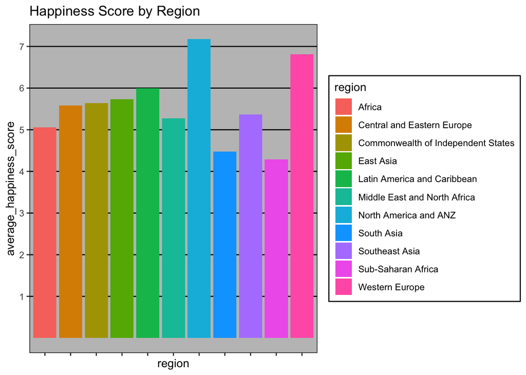

```r
world_happinessbrbar <- ggplot(worldhappinessbr, aes(region, average_happiness_score, fill = region))+
  geom_bar(stat = "identity")+
  theme_excel()+
  labs(title = "Happiness Score by Region")+
  scale_y_continuous(breaks = seq(1, 8, by = 1))+
  theme(axis.text.x = element_blank())

print(world_happinessbrbar)
```